# Reproducible Research

Project 1 MZ

**Total number of steps each day** Transform data

```r
setwd("C:\\users\\zhuangmg\\Coursera\\Reproducible Research\\project 1")
ActivityTable01<-read.csv("activity.csv")
ActivityTable02<-aggregate(ActivityTable01$steps,by=list(ActivityTable01$date),FUN=sum,na.rm=TRUE)
names(ActivityTable02)<-c("date","TotalSteps")
print(ActivityTable02)
```

```
##          date TotalSteps
## 1  2012-10-01          0
## 2  2012-10-02        126
## 3  2012-10-03      11352
## 4  2012-10-04      12116
## 5  2012-10-05      13294
## 6  2012-10-06      15420
## 7  2012-10-07      11015
## 8  2012-10-08          0
## 9  2012-10-09      12811
## 10 2012-10-10       9900
## 11 2012-10-11      10304
## 12 2012-10-12      17382
## 13 2012-10-13      12426
## 14 2012-10-14      15098
```

[output cut: 47 more lines]

**Total number of steps each day** Construct histogram of total number of steps each day

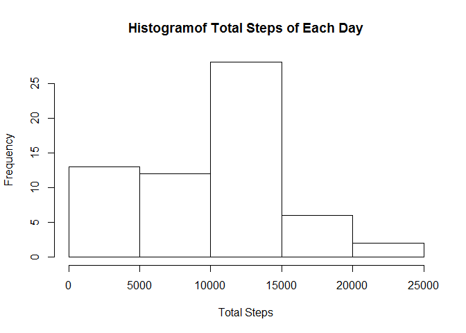

```r
hist(ActivityTable02$TotalSteps,main="Histogramof Total Steps of Each Day",xlab="Total Steps")
```

**Total number of steps each day** Calculate mean & median

```r
mean(ActivityTable02$TotalSteps)
```

```
## [1] 9354.23
```

```r
median(ActivityTable02$TotalSteps)
```

```
## [1] 10395
```

**Average daily activity pattern** Transform data

```r
ActivityTable03<-aggregate(ActivityTable01$steps,by=list(ActivityTable01$interval),FUN=mean,na.rm=TRUE)
names(ActivityTable03)<-c("interval","AverageSteps")
print(ActivityTable03)
```

```
##     interval AverageSteps
## 1          0    1.7169811
## 2          5    0.3396226
## 3         10    0.1320755
## 4         15    0.1509434
## 5         20    0.0754717
## 6         25    2.0943396
## 7         30    0.5283019
## 8         35    0.8679245
## 9         40    0.0000000
## 10        45    1.4716981
## 11        50    0.3018868
## 12        55    0.1320755
## 13       100    0.3207547
## 14       105    0.6792453
```

[output cut: 274 more lines]

**Average daily activity pattern** Plot time series data

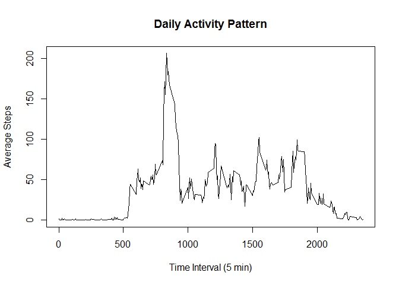

```r
plot(ActivityTable03$interval,ActivityTable03$AverageSteps,type = "l",main="Daily Activity Pattern",xlab="Time Interval (5 min)", ylab="Average Steps")
```

**Average daily activity pattern** Find the interval that contains the maximum number of steps

```r
ActivityTable03[which.max(ActivityTable03$AverageSteps),]
```

```
##     interval AverageSteps
## 104      835     206.1698
```

**Imputing missing values** calculate the total number of rows with missing values

```r
nrow(ActivityTable01[!complete.cases(ActivityTable01),])
```

```
## [1] 2304
```

**Imputing missing values** Impute missing values using the mean value of that interval and create a new dataset

```r
fillNA <- numeric()
for (i in 1:nrow(ActivityTable01)) {
    obs <- ActivityTable01[i, ]
    if (is.na(obs$steps)) {
        steps <- subset(ActivityTable03, interval == obs$interval)$AverageSteps
    } else {
        steps <- obs$steps
    }
    fillNA <- c(fillNA, steps)
}
ActivityTable04=ActivityTable01
ActivityTable04$steps=fillNA
nrow(ActivityTable04[!complete.cases(ActivityTable04),])
```

```
## [1] 0
```

Now ther is no missing values in the dataset

**Imputing missing values** Transform data, construct histogram of total number of steps each day, and compare with previous histogram

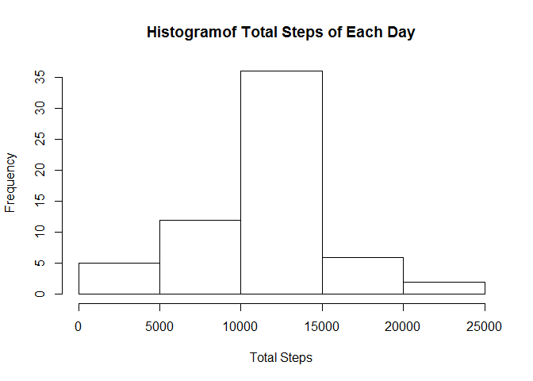

```r
ActivityTable05<-aggregate(ActivityTable04$steps,by=list(ActivityTable04$date),FUN=sum,na.rm=TRUE)
names(ActivityTable05)<-c("date","TotalSteps")
hist(ActivityTable05$TotalSteps,main="Histogramof Total Steps of Each Day",xlab="Total Steps")
```

This second histogram is different because of the imputation of missing values.

**Imputing missing values** Calculate mean & median and compare with previous values

```r
mean(ActivityTable05$TotalSteps)
```

```
## [1] 10766.19
```

```r
median(ActivityTable05$TotalSteps)
```

```
## [1] 10766.19
```

The mean and median are also different from previous values because of the imputation of missing values.

**Differences between weekdays and weekends** Create a new factor variable in the dataset with two levels - “weekday” and “weekend”

```r
ActivityTable04$date <- as.Date(ActivityTable04$date, "%Y-%m-%d")
ActivityTable04$weekdays<-weekdays(ActivityTable04$date)
ActivityTable04weekdays<-as.factor(ActivityTable04$weekdays)
ActivityTable04$daylevel=ActivityTable04$weekdays
for (i in 1:nrow(ActivityTable04)){
      if (ActivityTable04$weekdays[i]=="Saturday"){
      ActivityTable04$daylevel[i]<-"weekend"
    } else if (ActivityTable04$weekdays[i]=="Sunday"){
      ActivityTable04$daylevel[i]<-"weekend"
    } else {
      ActivityTable04$daylevel[i]<-"weekday"
    }
}
ActivityTable06 <- aggregate(steps~interval+daylevel,FUN=mean,data=ActivityTable04)
names(ActivityTable06)<-c("interval","daylevel","AverageSteps")
```

**Differences between weekdays and weekends**

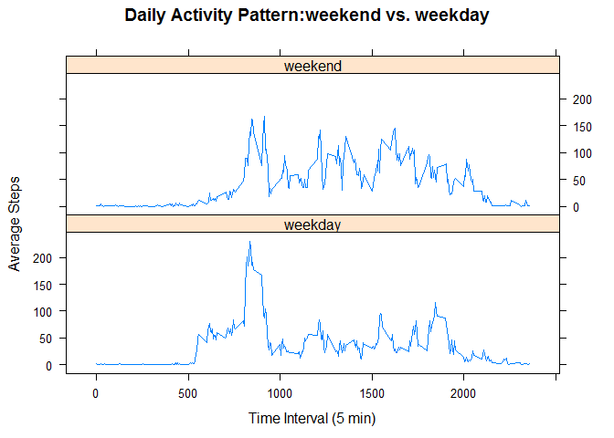

```r
library(lattice)
xyplot(AverageSteps ~ interval | daylevel,ActivityTable06, type = "l", layout = c(1, 2), main="Daily Activity Pattern:weekend vs. weekday",xlab="Time Interval (5 min)", ylab="Average Steps")
```

The patterns of weekday and weekend are slightly different.